# MA331-Report: 2211543

TED Talks by Speaker Arthur Benjamin and Speaker Scott McCloud

Palaniraj, Lokesh

## Introduction

In this report, I’ll be analysing & comparing the transcripts of the ted talks, ‘The visual magic of comics’ by **Scott McCloud** in 2009, where he spoke about the importance of visual comics right from his childhood, and his vision of its advancements in the future and ‘A performance of Mathemagic’ in 2007 by **Arthur Benjamin** where he performed stunning arithmetic calculations manually & verifying them with the audience’s calculators, ‘Teach statistics before calculus!’ in 2009 by **Arthur Benjamin** and speaking about the importance of statistics over calculus.

##### *Main objectives of this report:*

1. Summary and word count
2. Speakers’ top words comparison
3. Log odds ratio between the speakers
4. Sentiment analysis

## Results

As the ted_talks dataframe had a lot of different speakers data, I used *filter()* method to segregate the speakers allocated to me and stored them in a new dataframe called MyData. Then I used *unnest_tokens()* function to isolate the words from the entire text column and then used *anti_join()* function to remove the stop words and counted the words of different speeches using *count()* function, presented the plot according to the speeches and word counts. ‘talk_id’ attribute was used to differentiate between the speeches with same author name.

##### *Summary of MyData*

```
    talk_id        headline           speaker              views             word
 Min.   :199.0   Length:2834        Length:2834        Min.   :1076135   Length:2834
 1st Qu.:199.0   Class :character   Class :character   1st Qu.:1076135   Class :character
 Median :432.0   Mode  :character   Mode  :character   Median :1076135   Mode  :character
 Mean   :340.4                                         Mean   :4442239
 3rd Qu.:432.0                                         3rd Qu.:8636884
 Max.   :587.0                                         Max.   :8636884
```

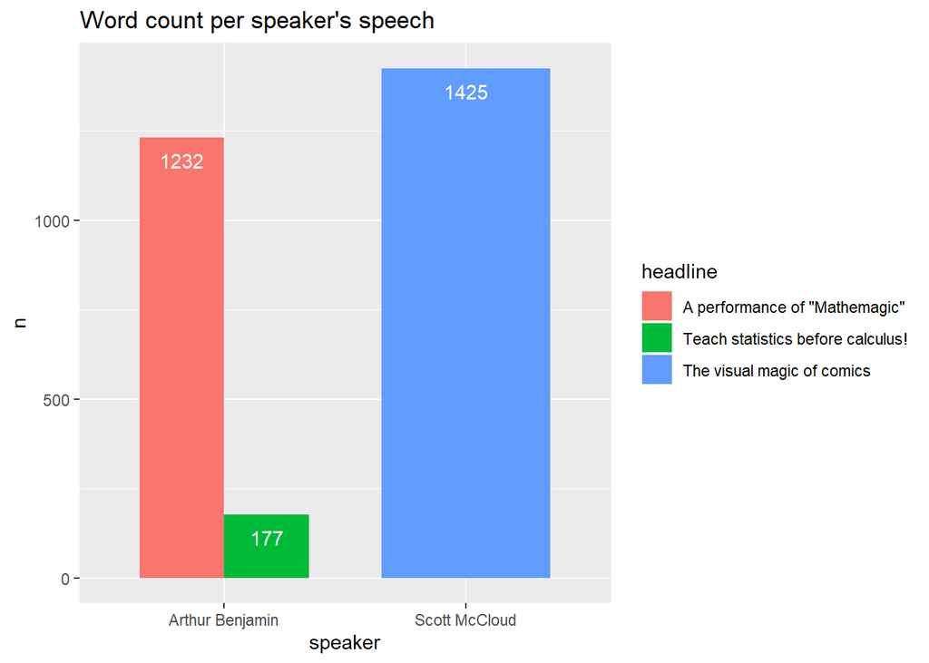

I used the following functions to interpret and compare both the speakers’ words and presented multiple plots like top words, sentiment analysis, etc. For counting the top words in both speakers’ words, the following functions has been used:

- *slice_max()* - to just visualize only the top 30 recurring words, this method has been used.
- *reorder()* - in my case, sorted my word column with respective to and stored it in word column using *mutate()*
- *ggplot()* - for plotting the bar graph with ‘n’ & ‘word’ as aesthetics with the help of *geom_col()* function.

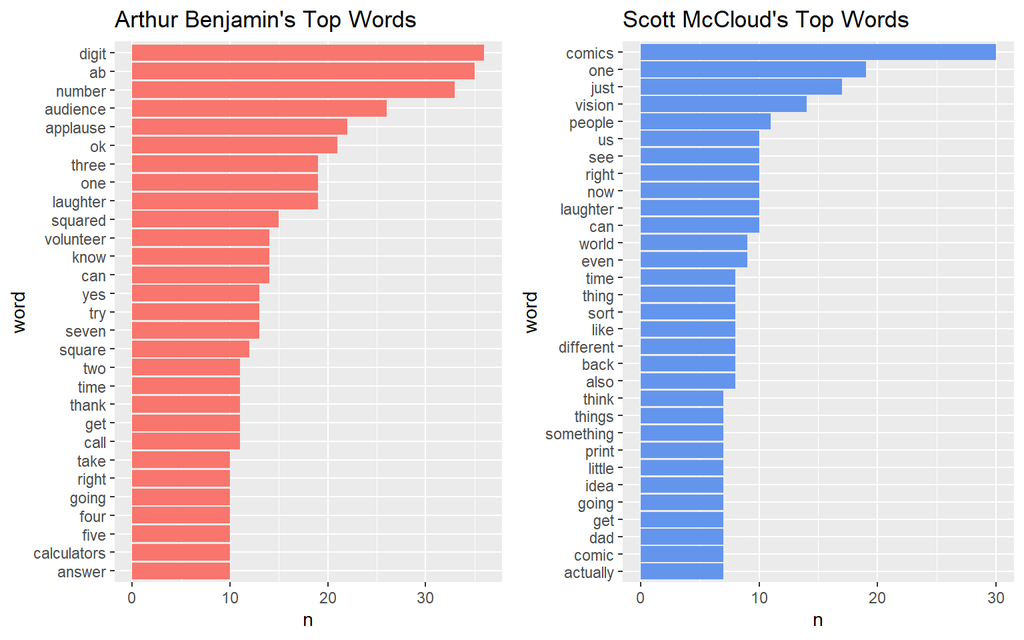

- *pivot_wider()* - here it is used to create columns based on each speaker’s top words count.
- *geom_abline()* - to draw a line to differentiate between the top words spoken by the speakers.

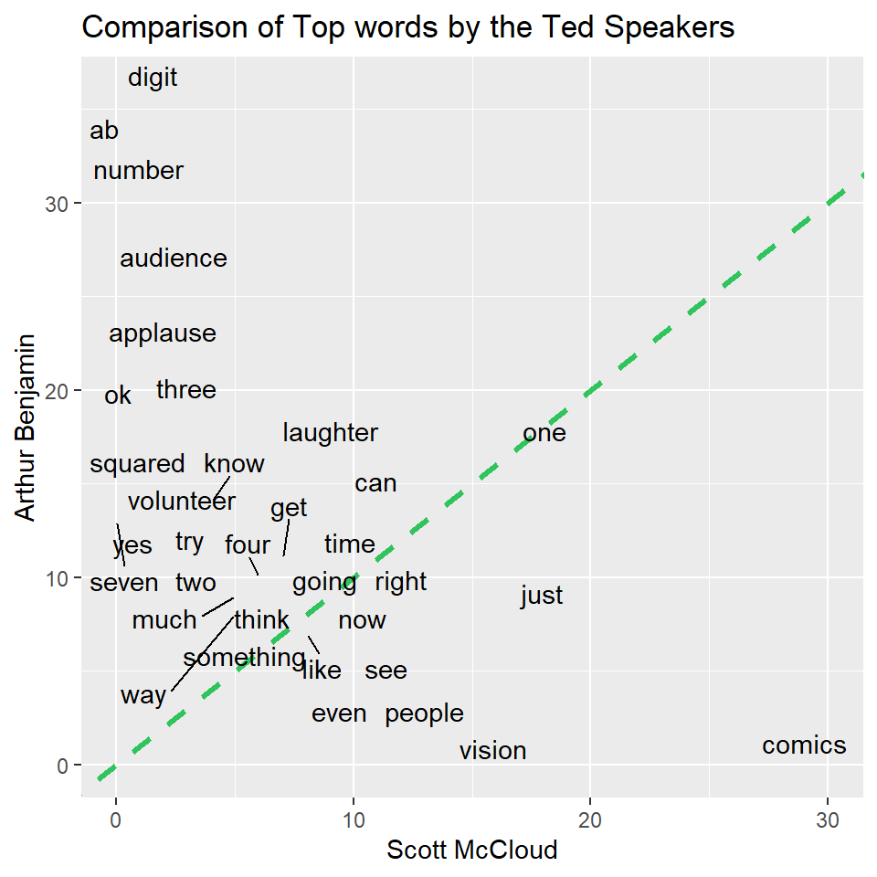

Here, I am performing the sentiment analysis with ‘nrc’ lexicon and presenting the table with n word sentiments in both the speakers and their corresponding OR values using the *compute_OR()* from dsEssex package.

| sentiment | Arthur_Benjamin | Scott_McCloud | OR | log_OR |
| --- | --- | --- | --- | --- |
| anger | 9 | 20 | 0.7002674 | -0.3562930 |
| anticipation | 31 | 33 | 1.5827365 | 0.4591553 |
| disgust | 4 | 8 | 0.7890625 | -0.2369097 |
| fear | 14 | 18 | 1.2521368 | 0.2248515 |
| joy | 16 | 24 | 1.0629630 | 0.0610603 |
| negative | 23 | 41 | 0.8755111 | -0.1329475 |
| positive | 48 | 84 | 0.8764479 | -0.1318780 |
| sadness | 9 | 26 | 0.5275607 | -0.6394914 |
| surprise | 15 | 15 | 1.6353591 | 0.4918624 |
| trust | 27 | 42 | 1.0232460 | 0.0229799 |

- *coord_flip()* - used this function to flip the coordinates of Log Odds ratio and the words from nrc sentiment.

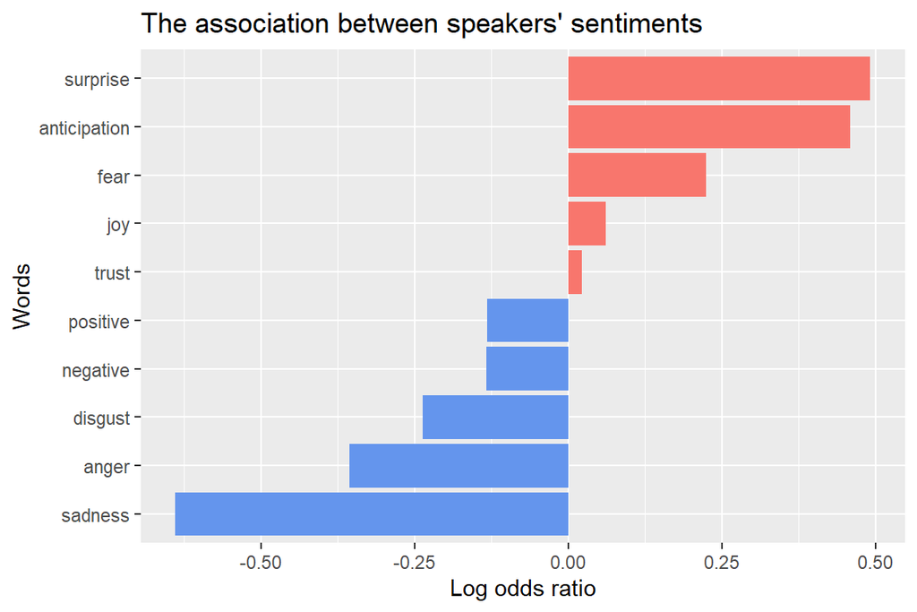

The following graph interprets the sentiment of the speakers’ words using ‘bing’ lexicon, where we filter the data according to the speaker and adding the sentiment column using *inner_join()* with respect to the words as positive or negative. The bars above 0 denotes a positive word and which are below 0 indicates a negative word. Finally, with the sentiment analysis, We can interpret that the speaker Arthur Benjamin’s speech was more optimistic than the speech of Scott McCloud’s, interpreted that with percentage pie chart of both the speakers.

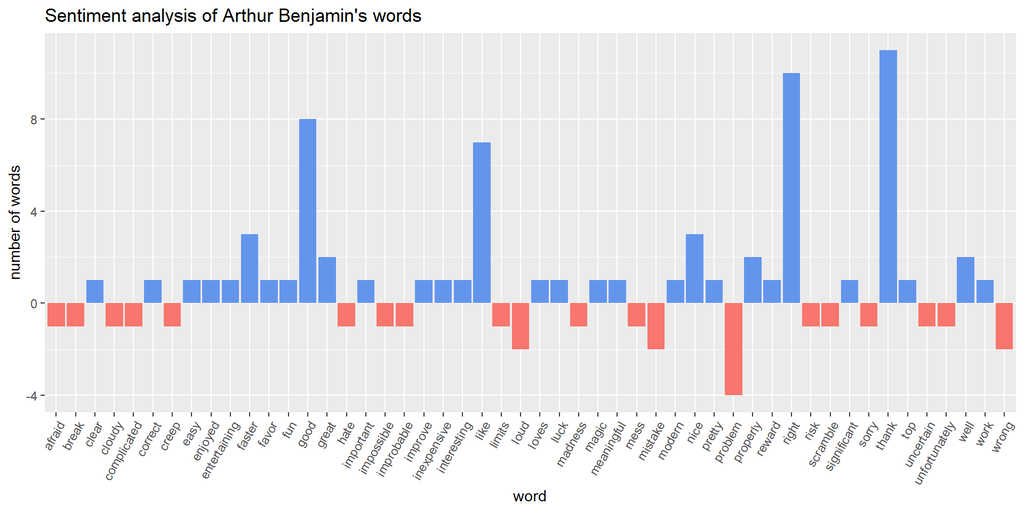

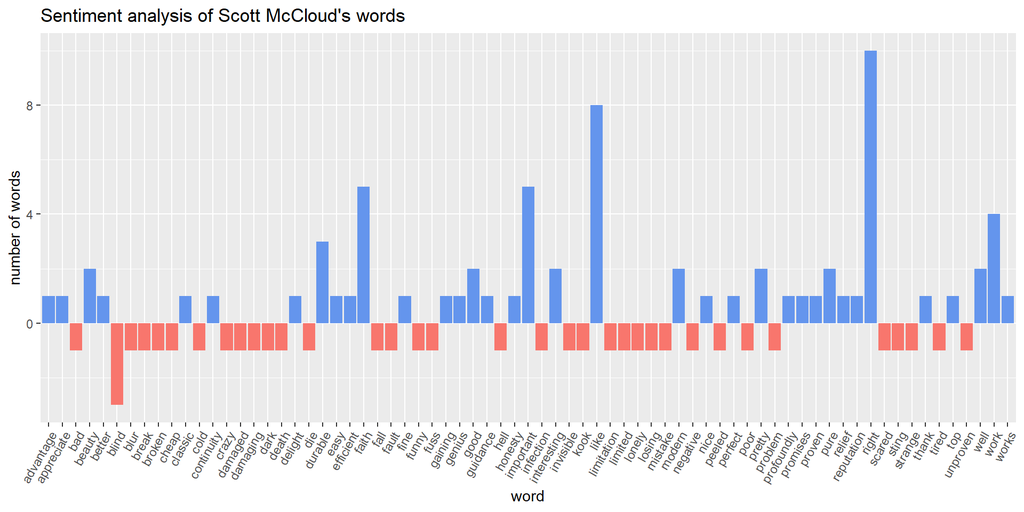

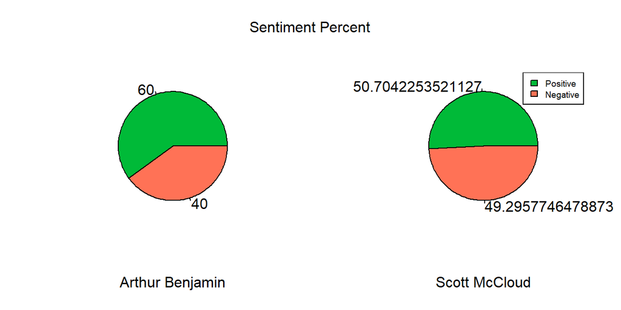